# The Impact of Religion on The Gender Gap Index

**Maygan Miguez and Jaclyn Wilson**  
Data Science Tutorial

[Link to our GitHub webpage](https://datasciencegendergapindex.github.io)

# **I. Introduction**

For centuries, religion has been an influential factor in the development of human beliefs, social interactions, and cultural differences. As politics, social issues, economic climates, and human health conditions evolve, one notable aspect of life that remains the same is religion.

Undoubtedly, religion is the strongest belief system that exists in the world. Religion has the power to influence cultural beliefs of an entire city, nation, or continent. Every religion plays an important role in the development of self-identity and morals on the individual level, which expands into social norms, government policies, and community ethics on the societial level.

Thus, a major religion can impact the social constructs of a country, including attitudes towards different genders. A key metric of a country's attitude towards the roles of men and women is the size of its gender gap. A large gender gap may indicate that a country's policies, societal norms, and opportunities are less advantageous for women. A small gender gap may indicate that a country's policies, societal norms, and opportunties are more equally advantageous to women and men.

## **Project Goals**

The goal of this project is to investigate and determine how a country's major religion(s) impact the size of its gender gap in terms of health, education, economics, and politics.

Three main questions that this project aims to answer are:  
**1. How does religion impact a country's gender gap subindex scores in terms of health, education, economics, and politics?**

**2. Are particular major religions related to a lower overall gender gap index score?**

**3. Can we predict how a country's gender gap index score will change over time based on the prediction of its future major religion?**

## **Project Datasets**

#### We are working with two datasets in this project:

1. [The Global Gender Gap Index](https://www.weforum.org/reports/ab6795a1-960c-42b2-b3d5-587eccda6023)  
   The Global Gender Gap Index benchmarks the evolution of gender-based gaps among four key dimensions (Economic Participation and Opportunity, Educational Attainment, Health and Survival, and Political Empowerment) and tracks progress towards closing these gaps over time.
2. [The Religious Composition By Country](https://www.pewforum.org/2015/04/02/religious-projection-table/2010/number/all/)  
   The Religious Composition By Country dataset from Pew Research Center details the estimated religious composition of 198 countries and territories from 2010 to 2050. The dataset also divides the world into six major regions and looks at how each region’s religious composition is likely to change from 2010 to 2050, assuming that current patterns in migration and other demographic trends continue.

## **Measuring The Global Gender Gap**

The Global Gender Gap Index is a score ranging from 0 to 1 with 0 being the lowest score and 1 being the highest score (indicating the gender gap is closed). Each country's index score is measured on four subindexes. Below is a description of how each of the four subindexes (Economic Participation and Opportunity, Educational Attainment, Health and Survival, and Political Empowerment) are measured by the World Economic Forum to create the Global Gender Gap Index. More information can be found at the [World Economic Forum's website](https://reports.weforum.org/global-gender-gap-report-2018/measuring-the-global-gender-gap/).

#### Economic Participation and Opportunity

This subindex contains three concepts: the participation gap, the remuneration gap and the advancement gap.

1. **Participation Gap**  
   This metric is captured using the difference between women and men in labour force participation rates.
2. **Remuneration Gap**  
   This metric is captured through a hard data indicator (ratio of estimated female-to-male earned income) and a qualitative indicator gathered through the World Economic Forum’s annual Executive Opinion Survey (wage equality for similar work).
3. **Gap Between Advancement of Women and Men**  
   This metric is captured through two hard data statistics (the ratio of women to men among legislators, senior officials and managers, and the ratio of women to men among technical and professional workers).

#### Educational Attainment

This subindex captures the gap between women’s and men’s current access to education through ratios of women to men in primary-, secondary- and tertiary-level education. A longer-term view of the country’s ability to educate women and men in equal numbers is captured through the ratio of the female literacy rate to the male literacy rate.

#### Health and Survival

This subindex provides an overview of the differences between women’s and men’s health through the use of two indicators.

1. **Sex Ratio at Birth**  
   This metric aims to capture the phenomenon of “missing women”, prevalent in many countries with a strong son preference.
2. **Gap Between Women’s and Men’s Healthy Life Expectancy**  
   This measure provides an estimate of the number of years that women and men can expect to live in good health by taking into account the years lost to violence, disease, malnutrition and other relevant factors.

#### Political Empowerment

This subindex measures the gap between men and women at the highest level of political decision-making through the ratio of women to men in ministerial positions and the ratio of women to men in parliamentary positions. In addition, the World Economic Forum included the ratio of women to men in terms of years in executive office (prime minister or president) for the last 50 years. A clear drawback in this category is the absence of any indicators capturing differences between the participation of women and men at local levels of government. Should such data become available at a globally comparative level in future years, it will be considered for inclusion in the Index.

## **External Factors That May Impact Our Model's Accuracy**

While the Global Gender Gap Index computes a country's overall gender gap score using the GGGI subindexes (economic, education, health and political), our model does not explore additional factors that may impact these subindexes other than religious groups. These additional factors could include a country's GDP, population density, access to natural resources, political freedom, level of corruption, development of technology, etc. It is important that we recognize our model's inability to account for these factors because we cannot make the assumption that a country's religion is the sole cause of a higher or lower GGGI score. In computing our model, we are making the assumption that these additional factors other than religion do not exist.

## **Collaboration Plan**

For our collaboration plan, we met on zoom once a week to work on the final project. We set up a google colab to work on our code together and made updates through this shared google colab. From November 18 to December 9, we developed our insights, visualizations, and presentation for the final project and presentation.

# **II. ETL (Extraction, Transform, and Load)**

## **Extraction**

#### Extracting & Loading The Religious Composition By Country Data

We extracted the dataset .xlsx file from [Pew Research Center](https://assets.pewresearch.org/wp-content/uploads/sites/11/2015/04/Religious_Composition_by_Country_2010-2050.xlsx) and loaded it as a Pandas dataframe. This dataset includes the level of specificity (1 = country, 2 = region, 3 = world), region ID number, year (in 10-year increments from 2010-2050), region, country, and estimated number of Christians, Muslims, Unaffiliated, Hindus, Buddhists, Folk Religions, Other Religions, Jews, and all religions for each country.

```python
import pandas as pd
import re
import numpy as np
```

```python
religion_df = pd.read_excel('https://assets.pewresearch.org/wp-content/uploads/sites/11/2015/04/Religious_Composition_by_Country_2010-2050.xlsx')
```

#### Extracting & Loading The Global Gender Gap Index Data

For the years 2010-2018, we extracted The Global Gender Gap Index data .tsv file from Yongqiang Xiong's [Analysis of the Global Gender Gap Index](https://github.com/yongqiangxiong/gggr_analysis) and loaded it as a Pandas dataframe. For the years 2020-2021, we extracted The Global Gender Gap Index data by converting the .pdf reports to .txt files. The dataset includes the year, each country's Gender Gap Index rank and score economic rank and score, education rank and score, health rank and score, and political rank and score.

**NOTE:** We were unable to extract data for the year 2019 because the World Economic Forum did not release a Global Gender Gap Index Report for 2019.

```python
# Extract 2010-2018 data from Yongqiang Xiong's Analysis of the Global Gender Gap Index and load as a Pandas dataframe
gggi_df = pd.read_csv('https://raw.githubusercontent.com/yongqiangxiong/gggr_analysis/b52f40026241444255d32483394f02913ab465b7/gggi-by-year.tsv', sep='\t')
gggi_df

# Extract 2020 data from txt files and load as a Pandas dataframe
gggi_econ_edu_2020_df = pd.read_csv('https://raw.githubusercontent.com/mmiguez1/mmiguez1.github.io/main/The%20Global%20Gender%20Gap%20Index%20Text%20(2019-2021)/WEF_GGGR_Economic_Education_2020.txt', delimiter=r"\s+", header=0, decimal=",")
gggi_health_pol_2020_df = pd.read_csv('https://raw.githubusercontent.com/mmiguez1/mmiguez1.github.io/main/The%20Global%20Gender%20Gap%20Index%20Text%20(2019-2021)/WEF_GGGR_Health_Political_2020.txt', delimiter=r"\s+", header=0, decimal=",")
gggi_overall_rank_2020_df = pd.read_csv('https://raw.githubusercontent.com/mmiguez1/mmiguez1.github.io/main/The%20Global%20Gender%20Gap%20Index%20Text%20(2019-2021)/WEF_GGGR_Overall_Rank_2020.txt', delimiter=r"\s+", header=0, decimal=",")

# Extract 2021 data from txt files and load as a Pandas dataframe
gggi_econ_edu_2021_df = pd.read_csv('https://raw.githubusercontent.com/mmiguez1/mmiguez1.github.io/main/The%20Global%20Gender%20Gap%20Index%20Text%20(2019-2021)/WEF_GGGR_Economic_Education_2021.txt', delimiter=r"\s+", header=0, decimal=",")
gggi_health_pol_2021_df = pd.read_csv('https://raw.githubusercontent.com/mmiguez1/mmiguez1.github.io/main/The%20Global%20Gender%20Gap%20Index%20Text%20(2019-2021)/WEF_GGGR_Health_Political_2021.txt', delimiter=r"\s+", header=0, decimal=",")
gggi_overall_rank_2021_df = pd.read_csv('https://raw.githubusercontent.com/mmiguez1/mmiguez1.github.io/main/The%20Global%20Gender%20Gap%20Index%20Text%20(2019-2021)/WEF_GGGR_Overall_Rank_2021.txt', delimiter=r"\s+", header=0, decimal=",")
```

## **Transformation & Tidying**

#### Tidying The Religious Composition Data

First, we tidy the Religious Composition data. Since the "row number" column is redundant, we use the .drop function to remove that column from the Religious Composition data. We also convert each column's data to its correct type.

```python
# Tidy Religious Composition data
religion_df = religion_df.drop(['row_number'], axis=1)

dtype_cols = ['Christians', 'Muslims', 'Unaffiliated', 'Hindus', 'Buddhists', 'Folk Religions', 'Other Religions', 'Jews', 'All Religions']

# Remove spaces, commas, and non-numeric signs
religion_df[dtype_cols] = religion_df[dtype_cols].stack().str.replace(',','').unstack()
religion_df[dtype_cols] = religion_df[dtype_cols].stack().str.replace(' ','').unstack()
religion_df[dtype_cols] = religion_df[dtype_cols].stack().str.replace('<','').unstack()

# Convert columns to correct datatypes
religion_df[dtype_cols] = religion_df[dtype_cols].apply(lambda x: pd.to_numeric(x, downcast="integer", errors='coerce'))
religion_df["Christians"] = religion_df["Christians"].fillna(0)
religion_df = religion_df.astype({'Christians': 'int64'})

display(religion_df)
display(religion_df.dtypes)
```

|  | level | Nation_fk | Year | Region | Country | Christians | Muslims | Unaffiliated | Hindus | Buddhists | Folk Religions | Other Religions | Jews | All Religions |
| --- | --- | --- | --- | --- | --- | --- | --- | --- | --- | --- | --- | --- | --- | --- |
| 0 | 3 | 10000 | 2010 | World | All Countries | 2168330000 | 1599700000 | 1131150000 | 1032210000 | 487760000 | 404690000 | 58150000 | 13860000 | 6895850000 |
| 1 | 2 | 1001 | 2010 | North America | All Countries | 266630000 | 3480000 | 59040000 | 2250000 | 3860000 | 1020000 | 2200000 | 6040000 | 344530000 |
| 2 | 2 | 1002 | 2010 | Latin America-Caribbean | All Countries | 531280000 | 840000 | 45390000 | 660000 | 410000 | 10040000 | 990000 | 470000 | 590080000 |
| 3 | 2 | 1003 | 2010 | Europe | All Countries | 553280000 | 43470000 | 139890000 | 1380000 | 1350000 | 870000 | 890000 | 1420000 | 742550000 |
| 4 | 2 | 1004 | 2010 | Middle East-North Africa | All Countries | 12710000 | 317070000 | 2100000 | 1720000 | 500000 | 1060000 | 230000 | 5630000 | 341020000 |
| ... | ... | ... | ... | ... | ... | ... | ... | ... | ... | ... | ... | ... | ... | ... |
| 1200 | 1 | 232 | 2050 | Sub-Saharan Africa | Zimbabwe | 16230000 | 200000 | 1430000 | 10000 | 10000 | 930000 | 50000 | 10000 | 18850000 |
| 1201 | 1 | 237 | 2050 | Sub-Saharan Africa | South Sudan | 12750000 | 1300000 | 100000 | 10000 | 10000 | 6930000 | 10000 | 10000 | 21080000 |
| 1202 | 1 | 238 | 2050 | Latin America-Caribbean | Curacao | 170000 | 10000 | 10000 | 10000 | 10000 | 10000 | 10000 | 10000 | 180000 |
| 1203 | 1 | 239 | 2050 | Latin America-Caribbean | Sint Maarten | 60000 | 10000 | 10000 | 10000 | 10000 | 10000 | 10000 | 10000 | 60000 |
| 1204 | 1 | 240 | 2050 | Latin America-Caribbean | Caribbean Netherlands | 20000 | 10000 | 10000 | 10000 | 10000 | 10000 | 10000 | 10000 | 20000 |

1205 rows × 14 columns

```
level               int64
Nation_fk           int64
Year                int64
Region             object
Country            object
Christians          int64
Muslims             int64
Unaffiliated        int32
Hindus              int32
Buddhists           int32
Folk Religions      int32
Other Religions     int32
Jews                int32
All Religions       int64
dtype: object
```

#### Tidying The Global Gender Gap Index Data

```python
# Tidy GGGI data for 2010-2018
tidy_gggi_df = gggi_df.filter(["#year", "country", "ggi_rank", "ggi_score", "eco_rank", "eco_score", "edu_rank", "edu_score", "health_rank", "health_score", "pol_rank", "pol_score"], axis=1)
tidy_gggi_df.rename(columns={"country":'Country', '#year': 'Year', 'ggi_rank':'Rank', 'ggi_score':'Score', 'eco_rank':'Economic_Rank', 'eco_score':'Economic_Score', \
                             'edu_rank':'Education_Rank', 'edu_score':'Education_Score', 'health_rank':'Health_Rank', 'health_score':'Health_Score', \
                             'pol_rank':'Political_Rank', 'pol_score':"Political_Score"}, inplace=True)

tidy_ggi_df= tidy_gggi_df[~tidy_gggi_df['Year'].isin(['2006', '2007', '2008', '2009'])]
```

In the previous section, we loaded six different .txt files for the 2020-2021 Global Gender Gap Index data. Each .txt file contains economic and education data, health and political data, or overall ranking and scores per year. Each .txt file resulted in a dataframe that contains two different columns for the two category rankings, scores, and countries. Therefore, we must break each one into two dataframes, rename columns to standard names, and concatenate the data to itself.

First, we separate our 2020 economic, education, health, and political data into two dataframes and rename the columns to standard names.

```python
# Separate 2020 Economic data into two dataframes & standardize column names
econ1_2020_df = gggi_econ_edu_2020_df.filter(['Country', 'Economic_Rank', 'Economic_Score_(0-1)'], axis = 1)
econ2_2020_df = gggi_econ_edu_2020_df.filter(['Country.1', 'Economic_Rank.1', 'Economic_Score_(0-1).1'], axis = 1)
econ2_2020_df = econ2_2020_df.rename(columns={'Country.1':'Country', 'Economic_Score_(0-1).1':'Economic_Score_(0-1)', 'Economic_Rank.1':'Economic_Rank'})

# Separate 2020 Education data into two dataframes & standardize column names
edu1_2020_df = gggi_econ_edu_2020_df.filter(['Country.2', 'Education_Rank', 'Education_Score_(0-1)'], axis=1)
edu1_2020_df = edu1_2020_df.rename(columns={'Country.2':'Country'})
edu2_2020_df = gggi_econ_edu_2020_df.filter(['Country.3', 'Education_Rank.1', 'Education_Score_(0-1).1'], axis=1)
edu2_2020_df = edu2_2020_df.rename(columns={'Country.3':'Country', 'Education_Score_(0-1).1':'Education_Score_(0-1)', 'Education_Rank.1':'Education_Rank'})

# Separate 2020 Health data into two dataframes & standardize column names
health1_2020_df = gggi_health_pol_2020_df.filter(['Country', 'Health/Survival_Rank', 'Health/Survival_Score_(0-1)'], axis = 1)
health2_2020_df = gggi_health_pol_2020_df.filter(['Country.1', 'Health/Survival_Rank.1', 'Health/Survival_Score_(0-1).1'], axis = 1)
health2_2020_df = health2_2020_df.rename(columns={'Country.1':'Country', 'Health/Survival_Score_(0-1).1':'Health/Survival_Score_(0-1)', 'Health/Survival_Rank.1':'Health/Survival_Rank'})

# Separate 2020 Political data into two dataframes & standardize column names
political1_2020_df = gggi_health_pol_2020_df.filter(['Country.2', 'Political_Rank', 'Political_Score_(0-1)'], axis=1)
political1_2020_df = political1_2020_df.rename(columns={'Country.2':'Country'})
political2_2020_df = gggi_health_pol_2020_df.filter(['Country.3', 'Political_Rank.1', 'Political_Score_(0-1).1'], axis=1)
political2_2020_df = political2_2020_df.rename(columns={'Country.3':'Country', 'Political_Score_(0-1).1':'Political_Score_(0-1)', 'Political_Rank.1':'Political_Rank'})
```

We must add a year column to the new dataframes so we can merge based on year later on.

```python
econ1_2020_df["Year"] = 2020
econ2_2020_df["Year"] = 2020
edu1_2020_df["Year"] = 2020
edu2_2020_df["Year"] = 2020
health1_2020_df["Year"] = 2020
health2_2020_df["Year"] = 2020
political1_2020_df["Year"] = 2020
political2_2020_df["Year"] = 2020
```

Next, we separate our 2021 economic, education, health, and political data into two dataframes and rename the columns to standard names.

```python
# Separate 2021 Economic data into two dataframes & standardize column names
econ1_2021_df = gggi_econ_edu_2021_df.filter(['Country', 'Economic_Rank', 'Economic_Score_(0-1)'], axis=1)
econ2_2021_df = gggi_econ_edu_2021_df.filter(['Country.1', 'Economic_Rank.1', 'Economic_Score_(0-1).1'], axis=1)
econ2_2021_df = econ2_2021_df.rename(columns={'Country.1':'Country', 'Economic_Score_(0-1).1':'Economic_Score_(0-1)', 'Economic_Rank.1':'Economic_Rank'})

# Separate 2021 Education data into two dataframes & standardize column names
edu1_2021_df = gggi_econ_edu_2021_df.filter(['Country.2', 'Education_Rank', 'Education_Score_(0-1)'], axis=1)
edu1_2021_df = edu1_2021_df.rename(columns={'Country.2':'Country'})
edu2_2021_df = gggi_econ_edu_2021_df.filter(['Country.3', 'Education_Rank.1', 'Education_Score_(0-1).1'], axis=1)
edu2_2021_df = edu2_2021_df.rename(columns={'Country.3':'Country', 'Education_Score_(0-1).1':'Education_Score_(0-1)', 'Education_Rank.1':'Education_Rank'})

# Separate 2021 Health data into two dataframes & standardize column names
health1_2021_df = gggi_health_pol_2021_df.filter(['Country', 'Health/Survival_Rank', 'Health/Survival_Score_(0-1)'], axis = 1)
health2_2021_df = gggi_health_pol_2021_df.filter(['Country.1', 'Health/Survival_Rank.1', 'Health/Survival_Score_(0-1).1'], axis = 1)
health2_2021_df = health2_2021_df.rename(columns={'Country.1':'Country', 'Health/Survival_Score_(0-1).1':'Health/Survival_Score_(0-1)', 'Health/Survival_Rank.1':'Health/Survival_Rank'})

# Separate 2021 Political data into two dataframes & standardize column names
political1_2021_df = gggi_health_pol_2021_df.filter(['Country.2', 'Political_Rank', 'Political_Score_(0-1)'], axis=1)
political1_2021_df = political1_2021_df.rename(columns={'Country.2':'Country'})
political2_2021_df = gggi_health_pol_2021_df.filter(['Country.3', 'Political_Rank.1', 'Political_Score_(0-1).1'], axis=1)
political2_2021_df = political2_2021_df.rename(columns={'Country.3':'Country', 'Political_Score_(0-1).1':'Political_Score_(0-1)', 'Political_Rank.1':'Political_Rank'})
```

Again, we add a year column to the new dataframes so we can merge based on year later on.

```python
econ1_2021_df["Year"] = 2021
econ2_2021_df["Year"] = 2021
edu1_2021_df["Year"] = 2021
edu2_2021_df["Year"] = 2021
health1_2021_df["Year"] = 2021
health2_2021_df["Year"] = 2021
political1_2021_df["Year"] = 2021
political2_2021_df["Year"] = 2021
```

Next, we tidy the overall score and rankings data for 2020 and 2021 by dropping columns with data we don't need. We then separate the data into two dataframes and rename columns.

```python
# Separate Overall data for 2020 into two dataframes & standardize column names
gggi_overall_rank_2020_df = gggi_overall_rank_2020_df.drop(['Rank_change_(2018)', 'Score_change_(2018)', 'Score_change_(2006)', 'Rank_change_(2018).1', 'Score_change_(2018).1', 'Score_change_(2006).1'], axis=1)
overall1_2020_df = gggi_overall_rank_2020_df.filter(['Rank', 'Country', 'Score'], axis=1)
overall2_2020_df = gggi_overall_rank_2020_df.filter(['Rank.1', 'Country.1', 'Score.1'], axis=1)
overall2_2020_df = overall2_2020_df.rename(columns={'Rank.1':'Rank', 'Country.1':'Country', 'Score.1':'Score'})

# Separate Overall data for 2020 into two dataframes & standardize column names
gggi_overall_rank_2021_df = gggi_overall_rank_2021_df.drop(['Rank_change_(2020)', 'Score_change_(2020)', 'Score_Change_(2006)', 'Rank_Change_(2020)', 'Score_Change_(2020)', 'Score_Change_(2006).1', 'Score.1', 'Score.3'], axis=1)
overall1_2021_df = gggi_overall_rank_2021_df.filter(['Rank', 'Country', 'Score'], axis=1)
overall2_2021_df = gggi_overall_rank_2021_df.filter(['Rank.1', 'Country.1', 'Score.2'], axis=1)
overall2_2021_df = overall2_2021_df.rename(columns={'Rank.1':'Rank', 'Country.1':'Country', 'Score.2':'Score'})
```

Again, we add a year column so we can merge based on year later on.

```python
overall1_2020_df["Year"] = 2020
overall2_2020_df["Year"] = 2020
overall1_2021_df["Year"] = 2021
overall2_2021_df["Year"] = 2021
```

After splitting up the data by category for each year (2020 and 2021), we can concatenate the data for both years together into category-specific dataframes.

```python
# Combine Economic, Education, Health, Political, and General data into one Dataframe per category
edu_df = pd.concat([edu1_2020_df, edu2_2020_df, edu1_2021_df, edu2_2021_df])
econ_df = pd.concat([econ1_2020_df, econ2_2020_df, econ1_2021_df, econ2_2021_df])
health_df = pd.concat([health1_2020_df, health2_2020_df, health1_2021_df, health2_2021_df])
political_df = pd.concat([political1_2020_df, political2_2020_df, political1_2021_df, political2_2021_df])
overall_df = pd.concat([overall1_2020_df, overall2_2020_df, overall1_2021_df, overall2_2021_df])
```

Now we can merge our new dataframes into one dataframe containing all ranks and scores for 2020 and 2021.

```python
# Merge Dataframes for both years into one
econ_edu_df = edu_df.merge(econ_df)
health_pol_df = health_df.merge(political_df)
eehp_df = econ_edu_df.merge(health_pol_df)
gggi_20_21_df = eehp_df.merge(overall_df, on=["Year", "Country"])
```

We can tidy our new dataframe containing all ranks and scores for 2020-2021 by renaming the columns to more concise names and making the format of values consistent.

```python
# Rename columns to more concise names
gggi_20_21_df = gggi_20_21_df.rename(columns={"Economic_Score_(0-1)":"Economic_Score",'Education_Score_(0-1)':"Education_Score", 'Health/Survival_Score_(0-1)':"Health_Score", \
                                          'Health/Survival_Rank':'Health_Rank', 'Political_Score_(0-1)':"Political_Score"})

# Clean up data inconsistencies
gggi_20_21_df = gggi_20_21_df.replace({'-': np.nan, 'n/a': np.nan})
```

```python
# Merge data for 2020-2021 with data for 2010-2018
all_gggi_df = pd.concat([tidy_gggi_df, gggi_20_21_df])

# Convert columns to correct datatypes
float_cols = ['Score', 'Economic_Score', 'Education_Score', 'Health_Score', 'Political_Score']
all_gggi_df[float_cols] = all_gggi_df[float_cols].apply(pd.to_numeric, axis=1)
all_gggi_df = all_gggi_df.astype({'Rank':'int64', 'Education_Rank':'int64', 'Health_Rank':'int64', 'Political_Rank':'int64'})

display(all_gggi_df)
display(all_gggi_df.dtypes)
```

|  | Year | Country | Rank | Score | Economic_Rank | Economic_Score | Education_Rank | Education_Score | Health_Rank | Health_Score | Political_Rank | Political_Score |
| --- | --- | --- | --- | --- | --- | --- | --- | --- | --- | --- | --- | --- |
| 0 | 2006 | Albania | 61 | 0.661 | 38 | 0.661 | 58 | 0.989 | 110 | 0.955 | 105 | 0.038 |
| 1 | 2006 | Algeria | 97 | 0.602 | 103 | 0.443 | 84 | 0.944 | 78 | 0.971 | 98 | 0.049 |
| 2 | 2006 | Angola | 96 | 0.604 | 69 | 0.587 | 107 | 0.779 | 1 | 0.980 | 81 | 0.070 |
| 3 | 2006 | Argentina | 41 | 0.683 | 82 | 0.551 | 29 | 0.997 | 1 | 0.980 | 23 | 0.204 |
| 4 | 2006 | Australia | 15 | 0.716 | 12 | 0.726 | 1 | 1.000 | 57 | 0.976 | 32 | 0.163 |
| ... | ... | ... | ... | ... | ... | ... | ... | ... | ... | ... | ... | ... |
| 287 | 2021 | Benin | 123 | 0.653 | 9 | 0.814 | 150 | 0.733 | 70 | 0.973 | 131 | 0.093 |
| 288 | 2021 | Niger* | 138 | 0.629 | 82 | 0.673 | 151 | 0.726 | 124 | 0.964 | 97 | 0.155 |
| 289 | 2021 | Yemen | 155 | 0.492 | 154 | 0.282 | 152 | 0.717 | 95 | 0.968 | 154 | 0.001 |
| 290 | 2021 | Guinea | 118 | 0.660 | 6 | 0.839 | 153 | 0.680 | 109 | 0.966 | 96 | 0.157 |
| 291 | 2021 | Chad | 148 | 0.593 | 73 | 0.693 | 155 | 0.589 | 81 | 0.970 | 119 | 0.118 |

2063 rows × 12 columns

```
Year                 int64
Country             object
Rank                 int64
Score              float64
Economic_Rank        int64
Economic_Score     float64
Education_Rank       int64
Education_Score    float64
Health_Rank          int64
Health_Score       float64
Political_Rank       int64
Political_Score    float64
dtype: object
```

#### Checking Country Name Consistency

In order to accurately combine the values from the Religous Composition data with the Global Gender Gap Index data, we must correct any inconsistent spelling or punctuation of country names. We can do this by left joining our two datasets and creating a new dataframe with only the left values to see which country names are different. Once we determine which names need to be changed, we can replace them with their correct spelling and punctuation.

```python
#checks which rows were not merged from the all_gggi_df so that we can see which country names are different and need to be renamed
rename_df=pd.merge(all_gggi_df,religion_df[['Country']],on=['Country'],how="outer",indicator=True)
rename_df=rename_df[rename_df['_merge']=='left_only']
rename_df = rename_df.drop_duplicates(subset='Country', keep='first')

#Renaming some of the country
all_gggi_df = all_gggi_df.replace("Russian_Federation", "Russia")
all_gggi_df = all_gggi_df.replace(r'\_+', ' ', regex=True)
all_gggi_df = all_gggi_df.replace({'*':'', 'Korea Rep.':'South Korea', 'Kyrgyz Republic': 'Kyrgyzstan', 'Macedonia':'Republic of Macedonia', 'Russian Federation':'Russia', \
                                   'Slovak Republic':'Slovakia', 'Macedonia,FYR':'Republic of Macedonia', 'Brunei Darussalam':'Brunei', 'Lao PDR':'Laos', \
                                   'Bosnia and Herzegovina':'Bosnia-Herzegovina', 'Myanmar':'Burma (Myanmar)', 'Congo, Dem. Rep.':'Democratic Republic of the Congo', \
                                   'Zambia*': 'Zambia', 'Guyana*': 'Guyana', 'North Macedonia': 'Republic of Macedonia', 'United States of America':'United States', \
                                   'W. Sahara':'Western Sahara'})
```

# **III. Exploratory Data Analysis (EDA)**

For our exploratory data analysis of The Global Gender Gap Index and Religious Composition data, we first get familiar with the summary statistics of our data. Next, we analyze both datasets to gain general answers to two of our project questions.

```python
%%time
!apt install gdal-bin python-gdal python3-gdal   # Important library for many geopython libraries
!apt install python3-rtree   # Install rtree - Geopandas requirment
!pip install git+git://github.com/geopandas/geopandas.git   # Install Geopandas
!pip install descartes   # Install descartes - Geopandas requirment
!pip install folium   # Install Folium for Geographic data visualization
!pip install plotly_express   # Install plotlyExpress
```

[output not shown]

[output cut: 22 more lines]

[output not shown]

```python
import seaborn as sns
import matplotlib.pyplot as plt
import geopandas as geo
from shapely.geometry import Point
import matplotlib
import matplotlib.pyplot as plt
import folium
import plotly_express as px
import altair as alt
```

## **Summary Statistics**

#### The Gender Gap Index Summary Statistics

```python
all_gggi_df.describe()
```

|  | Year | Rank | Score | Economic_Rank | Economic_Score | Education_Rank | Education_Score | Health_Rank | Health_Score | Political_Rank | Political_Score |
| --- | --- | --- | --- | --- | --- | --- | --- | --- | --- | --- | --- |
| count | 2063.000000 | 2063.000000 | 2063.000000 | 2063.000000 | 2063.000000 | 2063.000000 | 2063.000000 | 2063.000000 | 2063.000000 | 2063.000000 | 2063.000000 |
| mean | 2013.394086 | 69.907416 | 0.686941 | 69.931653 | 0.640637 | 67.963645 | 0.953069 | 64.898206 | 0.971943 | 69.959767 | 0.182244 |
| std | 4.502538 | 40.509553 | 0.060744 | 40.583770 | 0.121293 | 43.228748 | 0.082809 | 46.397121 | 0.010015 | 40.529914 | 0.132888 |
| min | 2006.000000 | 1.000000 | 0.451000 | 1.000000 | 0.195000 | 1.000000 | 0.468000 | 1.000000 | 0.915000 | 1.000000 | 0.000000 |
| 25% | 2010.000000 | 35.000000 | 0.651000 | 35.000000 | 0.584000 | 35.000000 | 0.951000 | 1.000000 | 0.969000 | 35.000000 | 0.087000 |
| 50% | 2013.000000 | 70.000000 | 0.690000 | 70.000000 | 0.659000 | 69.000000 | 0.991000 | 69.000000 | 0.974000 | 70.000000 | 0.145000 |
| 75% | 2017.000000 | 104.000000 | 0.722000 | 104.000000 | 0.726000 | 104.000000 | 0.999000 | 104.000000 | 0.980000 | 104.000000 | 0.248000 |
| max | 2021.000000 | 155.000000 | 0.892000 | 155.000000 | 0.915000 | 155.000000 | 1.000000 | 156.000000 | 0.980000 | 155.000000 | 0.760000 |

#### Religious Composition Summary Statistics

Here we look at the summary statistics for the Religious Composition data. We can see that on average, countries have more Christians and Muslims than other religions. However, we must take into account that the dominating religion of larger countries may have a greater impact on the data averages.

```python
religion_df.describe()
```

|  | level | Nation_fk | Year | Christians | Muslims | Unaffiliated | Hindus | Buddhists | Folk Religions | Other Religions | Jews | All Religions |
| --- | --- | --- | --- | --- | --- | --- | --- | --- | --- | --- | --- | --- |
| count | 1205.000000 | 1205.000000 | 1205.000000 | 1.205000e+03 | 1.205000e+03 | 1.205000e+03 | 1.205000e+03 | 1.205000e+03 | 1.205000e+03 | 1.205000e+03 | 1.205000e+03 | 1.205000e+03 |
| mean | 1.033195 | 181.286307 | 2030.000000 | 3.187832e+07 | 2.732775e+07 | 1.502062e+07 | 1.541210e+07 | 6.220664e+06 | 5.433477e+06 | 7.657759e+05 | 1.958672e+05 | 1.022204e+08 |
| std | 0.201061 | 652.395920 | 14.148007 | 1.836824e+08 | 1.715920e+08 | 1.060028e+08 | 1.348549e+08 | 4.787220e+07 | 4.166840e+07 | 5.476515e+06 | 1.270617e+06 | 6.281590e+08 |
| min | 1.000000 | 1.000000 | 2010.000000 | 0.000000e+00 | 1.000000e+04 | 1.000000e+04 | 1.000000e+04 | 1.000000e+04 | 1.000000e+04 | 1.000000e+04 | 1.000000e+04 | 1.000000e+04 |
| 25% | 1.000000 | 61.000000 | 2020.000000 | 1.300000e+05 | 1.000000e+04 | 1.000000e+04 | 1.000000e+04 | 1.000000e+04 | 1.000000e+04 | 1.000000e+04 | 1.000000e+04 | 5.100000e+05 |
| 50% | 1.000000 | 121.000000 | 2030.000000 | 1.210000e+06 | 1.600000e+05 | 8.000000e+04 | 1.000000e+04 | 1.000000e+04 | 1.000000e+04 | 1.000000e+04 | 1.000000e+04 | 6.330000e+06 |
| 75% | 1.000000 | 183.000000 | 2040.000000 | 8.100000e+06 | 3.740000e+06 | 1.000000e+06 | 2.000000e+04 | 2.000000e+04 | 1.800000e+05 | 3.000000e+04 | 1.000000e+04 | 2.871000e+07 |
| max | 3.000000 | 10000.000000 | 2050.000000 | 2.918070e+09 | 2.761480e+09 | 1.244190e+09 | 1.384360e+09 | 5.113000e+08 | 4.519100e+08 | 6.255000e+07 | 1.609000e+07 | 9.307190e+09 |

## **Distributions**

#### The Gender Gap Index Distributions

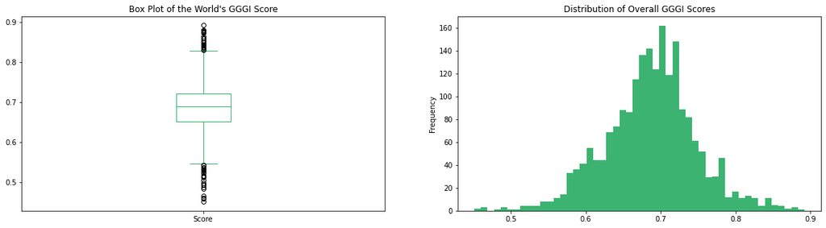

```python
fig, ax = plt.subplots(1, 2, figsize=(20,5))
fig1 = all_gggi_df['Score'].plot.box(ax=ax[0], title="Box Plot of the World's GGGI Score", color='mediumseagreen')
fig2 = all_gggi_df['Score'].plot.hist(bins = 50, ax = ax[1], title="Distribution of Overall GGGI Scores", color='mediumseagreen')
```

Here, we look at the average of the GGI subindexes over the past 15 years. This graph informs us that on average, political and economic scores worldwide are the lowest.

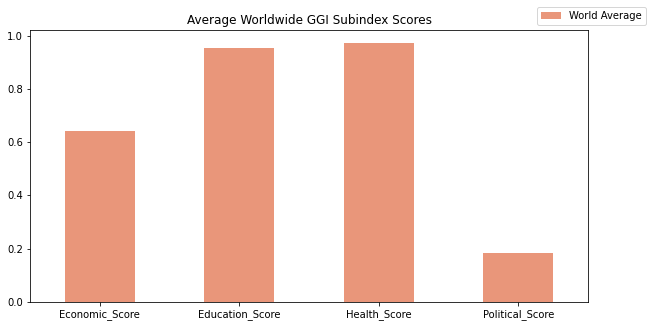

```python
new_all_gggi_df = all_gggi_df[['Year','Country', 'Economic_Score', 'Education_Score', 'Health_Score', 'Political_Score']]
new_all_gggi_df = new_all_gggi_df.set_index('Year')
new_all_gggi_df.mean().plot(kind="bar", label='World Average', title='Average Worldwide GGI Subindex Scores', figsize=(10,5), color='darksalmon', rot=360)
plt.legend(loc="lower left",bbox_to_anchor=(0.9,1.0))
plt.show()
```

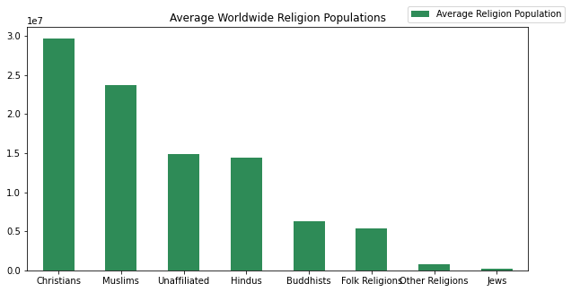

```python
spec_religion_df = religion_df[(religion_df['Year'] == 2020)].copy()
spec_religion_df = spec_religion_df[['Christians', 'Muslims', 'Unaffiliated', 'Hindus', 'Buddhists', 'Folk Religions', 'Other Religions', 'Jews']]
spec_religion_df.mean().plot(kind="bar", label='Average Religion Population', title='Average Worldwide Religion Populations', figsize=(10,5), color='seagreen', rot=360)
plt.legend(loc="lower left",bbox_to_anchor=(0.75,1.0))
plt.show()
```

## **Relationship Strength**

Next, we explore the strengths of the relationship between the different metrics including economic, political, health, education, and overall rank. Both the correlation matrix and heatmap show that the political and economic metrics have the strongest correlations with the overall score. This means that a lot of the political policies, political opportunities, and economic opportunities strongly affect the gender gap index.

This is interesting because politics can play a huge role in gender equality. Throughout history, politics have often played roles in granting equal rights and opportunities for women.

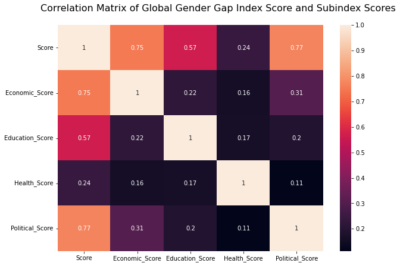

|  | Score | Economic_Score | Education_Score | Health_Score | Political_Score |
| --- | --- | --- | --- | --- | --- |
| Score | 1.000000 | 0.751156 | 0.565653 | 0.240833 | 0.772235 |
| Economic_Score | 0.751156 | 1.000000 | 0.223157 | 0.164396 | 0.309088 |
| Education_Score | 0.565653 | 0.223157 | 1.000000 | 0.166027 | 0.195063 |
| Health_Score | 0.240833 | 0.164396 | 0.166027 | 1.000000 | 0.112411 |
| Political_Score | 0.772235 | 0.309088 | 0.195063 | 0.112411 | 1.000000 |

```python
#Drop columns corresponding with rank to only look at the scores
all_gggi_score = all_gggi_df
all_gggi_score = all_gggi_score.drop(columns = ["Year", "Rank", "Economic_Rank", "Education_Rank", "Health_Rank", "Political_Rank"])
corr_score = all_gggi_score.corr()

# Plot correlation matrix and heatmap
f, ax = plt.subplots(figsize=(10,7))
f.suptitle("Correlation Matrix of Global Gender Gap Index Score and Subindex Scores", fontsize=16, y=0.95)
sns.heatmap(corr_score, annot = True)
plt.show()
corr_score
```

## **Geographic Visualization**

Here, we visualize the data in terms of its geographic location. This enables us to better understand religion and gender gap scores in broader regional terms which will help us determine if a specific religion impacts countries' gender gap score.

We can plot our data by geographic location using the Geopandas library.

#### The Gender Gap Index Geographic Visualization

In the Choropleth map of the Gender Gap Index scores by country, we see that countries in eastern areas tend to have a lower gender gap score. This tells us that gender gap scores tend to be similar among countries in the same geographic region.

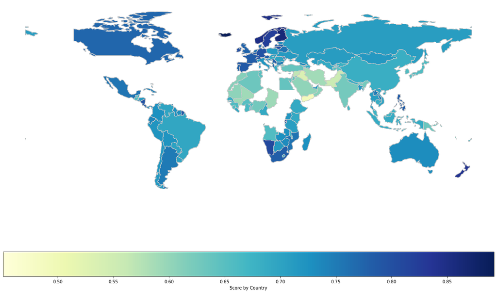

```python
#Join the two tables based on the country
table_new = religion_df.join(all_gggi_df.set_index(["Country"])["Rank"].to_frame("Rank"), on=["Country"])
table_new = table_new.join(all_gggi_df.set_index(["Country"])["Score"].to_frame("Score"), on=["Country"])

#Find the proportions of all religions
table_new["Christians_porp"] = table_new["Christians"]/table_new["All Religions"]
table_new["Muslims_porp"] = table_new["Muslims"]/table_new["All Religions"]
table_new["Unaffiliated_porp"] = table_new["Unaffiliated"]/table_new["All Religions"]
table_new["Hindus_porp"] = table_new["Hindus"]/table_new["All Religions"]
table_new["Buddhists_porp"] = table_new["Buddhists"]/table_new["All Religions"]
table_new["Folk Religions porp"] = table_new["Folk Religions"]/table_new["All Religions"]
table_new["Other_porp"] = table_new["Other Religions"]/table_new["All Religions"]
table_new["Jews_porp"] = table_new["Jews"]/table_new["All Religions"]

#world contains the information for each country and its shape
world = geo.read_file(geo.datasets.get_path("naturalearth_lowres"))

f1 = table_new.merge(world, left_on="Country", right_on="name", how="outer", indicator=True)
f1=f1[f1['_merge']=='left_only']
f1 = f1.drop_duplicates(subset='Country', keep='first')

#Combine the dataframes to use for plot
world_score = world.merge(table_new, left_on="name", right_on="Country")
world_score = world_score.drop(columns = ["Christians",	"Muslims",	"Unaffiliated",	"Hindus",	"Buddhists",	"Folk Religions",	"Other Religions",	"Jews"])
world_score = world_score.dropna(0)
#set the range for the choropleth
vmin, vmax = 120, 220
# create figure and axes for Matplotlib
fig, ax = plt.subplots(1, figsize=(20, 15))

world_score.plot(column='Score', cmap='YlGnBu', linewidth=0.8, ax=ax, edgecolor = '0.8', legend=True, legend_kwds = {'label': "Score by Country", 'orientation': "horizontal"})
ax.set_axis_off()
plt.show()

## NOTE: I will later fix the names of each country too
```

#### Religious Composition Geographic Visualization

In the choropleth map of the religious composition data, we can see that countries in the same geographic region tend to have the same major religion. We can also see the geographic spread of each religion. In particular, Christianity appears to be the most geographically spread out religion.

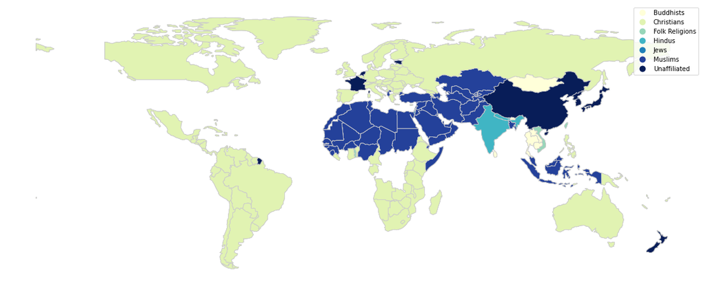

```python
# Create a seperate column Max that has which of the religious populations is largest in that country
for_religion = religion_df
for_religion['Max'] = for_religion[["Christians",	"Muslims",	"Unaffiliated",	"Hindus",	"Buddhists",	"Folk Religions",	"Other Religions",	"Jews"]].idxmax(axis=1)
world_religion = world.merge(for_religion, left_on="name", right_on="Country")

# Set the range for the choropleth
vmin, vmax = 120, 220

# Create figure and axes for Matplotlib
fig, ax = plt.subplots(1, figsize=(20, 15))
world_religion.plot(column='Max', cmap='YlGnBu', linewidth=0.8, ax=ax, edgecolor = '0.8', legend=True)
ax.set_axis_off()
plt.show()

## NOTE: I will later fix the names of each country too
```

## **Model Hypothesis**

From our exploratory data analysis, we determined that we can create a model to accomplish two things:

1. We can evaluate how religion impacts overall scores and subindex scores by determining the correlations between overall score and religion as well as subindex score and religion
1. We can predict a country's GGGI score from its predicted major religion or proportion of religions.

# **IV. Evaluating How Religion Impacts Subindex Scores**

## **Determining How Religion Impacts a Country's Gender Gap Subindex Scores & Overall Score**

As mentioned in our External Factors That May Impact Our Model's Accuracy section, we must remember that there are additional factors that may impact a country's subindex scores other than religion and that our model assumes these factors do not exist.

In order to visualize how each religion correlates to each subindex score, we graph scatter plots of each subindex score with each religion and fit the data with a regression line to better visualize correlation. Each point on the scatter plots represents the proportion of a particular religion in a country and that country's particular subindex score.

To plot the religion data, we must first compute the proportions of religious groups of each country in our dataset. To compute this, we divide the number of members of each religious group by the total number of members of all religious groups combined. It is important for us to use these proportions instead of the number of members for each religious group in each country because countries with larger populations or more religious citizens will have a greater weight than those with smaller populations or less religious citizens. By taking the proportions of each group, we can standardize all of the religious group variables to be measured on the same scale.

```python
# Create dataframe for subindexes and religions
subindex_rel_df = all_gggi_df.merge(religion_df, how='inner', on=['Country', 'Year'], sort=True)

# Create lists of columns
religion_list = ['Muslims', 'Unaffiliated', 'Christians', 'Hindus', 'Buddhists', 'Folk Religions', 'Other Religions', 'Jews']
prop_religion_list = ['Muslims Proportion', 'Unaffiliated Proportion', 'Christians Proportion', 'Hindus Proportion', 'Buddhists Proportion', 'Folk Religions Proportion', 'Other Religions Proportion', 'Jews Proportion']
subindex_list = ['Economic_Score', 'Education_Score', 'Health_Score', 'Political_Score']

# Loop through list of columns and compute religion proportions for each column
for (i,j) in zip(religion_list, prop_religion_list):
    subindex_rel_df[j] = subindex_rel_df[i]/subindex_rel_df["All Religions"]

# Drop unnecessary columns
subindex_rel_df_2020 = subindex_rel_df.loc[subindex_rel_df['Year'] > 2019].copy()
subindex_rel_df_2020 = subindex_rel_df_2020.drop(columns=['All Religions', 'Year', 'level', 'Rank', 'Score', 'Economic_Rank', 'Education_Rank', 'Health_Rank', 'Political_Rank', 'Nation_fk', \
                                        'Muslims', 'Unaffiliated', 'Christians', 'Hindus', 'Buddhists', 'Folk Religions', 'Other Religions', 'Jews'])

# Create individual subindex/religion dataframes for plotting
df1,df2,df3,df4 = subindex_rel_df_2020[['Muslims Proportion', 'Economic_Score']], subindex_rel_df_2020[['Muslims Proportion', 'Education_Score']], subindex_rel_df_2020[['Muslims Proportion', 'Health_Score']], subindex_rel_df_2020[['Muslims Proportion', 'Political_Score']]
df5,df6,df7,df8 = subindex_rel_df_2020[['Unaffiliated Proportion', 'Economic_Score']], subindex_rel_df_2020[['Unaffiliated Proportion', 'Education_Score']], subindex_rel_df_2020[['Unaffiliated Proportion', 'Health_Score']], subindex_rel_df_2020[['Unaffiliated Proportion', 'Political_Score']]
df9,df10,df11,df12 = subindex_rel_df_2020[['Christians Proportion', 'Economic_Score']], subindex_rel_df_2020[['Christians Proportion', 'Education_Score']], subindex_rel_df_2020[['Christians Proportion', 'Health_Score']], subindex_rel_df_2020[['Christians Proportion', 'Political_Score']]
df13,df14,df15,df16 = subindex_rel_df_2020[['Hindus Proportion', 'Economic_Score']], subindex_rel_df_2020[['Hindus Proportion', 'Education_Score']], subindex_rel_df_2020[['Hindus Proportion', 'Health_Score']], subindex_rel_df_2020[['Hindus Proportion', 'Political_Score']]
df17,df18,df19,df20 = subindex_rel_df_2020[['Buddhists Proportion', 'Economic_Score']], subindex_rel_df_2020[['Buddhists Proportion', 'Education_Score']], subindex_rel_df_2020[['Buddhists Proportion', 'Health_Score']], subindex_rel_df_2020[['Buddhists Proportion', 'Political_Score']]
df21,df22,df23,df24 = subindex_rel_df_2020[['Folk Religions Proportion', 'Economic_Score']], subindex_rel_df_2020[['Folk Religions Proportion', 'Education_Score']], subindex_rel_df_2020[['Folk Religions Proportion', 'Health_Score']], subindex_rel_df_2020[['Folk Religions Proportion', 'Political_Score']]
df25,df26,df27,df28 = subindex_rel_df_2020[['Other Religions Proportion', 'Economic_Score']], subindex_rel_df_2020[['Other Religions Proportion', 'Education_Score']], subindex_rel_df_2020[['Other Religions Proportion', 'Health_Score']], subindex_rel_df_2020[['Other Religions Proportion', 'Political_Score']]
df29,df30,df31,df32 = subindex_rel_df_2020[['Jews Proportion', 'Economic_Score']], subindex_rel_df_2020[['Jews Proportion', 'Education_Score']], subindex_rel_df_2020[['Jews Proportion', 'Health_Score']], subindex_rel_df_2020[['Jews Proportion', 'Political_Score']]
```

#### Economic Score vs. Religion Proportion Visualization

First, we plot each country's economic score with its proportions for each religion in our dataset. In the plots below, we can see that Christianity and Unaffiliated have a positive correlation with economic score. Islam has a negative correlation with economic score, and Hinduism has a slightly negative correlation with economic score. Buddhism, Folk Religions, Other, and Judaism have almost no correlation with economic score.

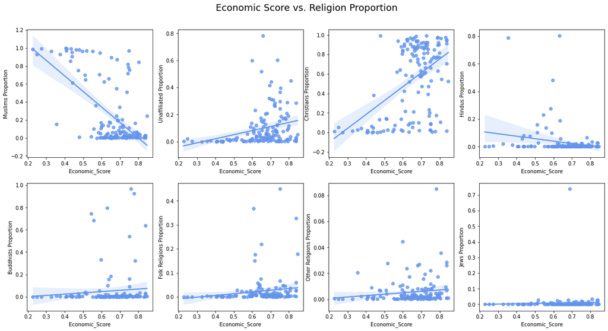

```python
# Create list of dataframe containing economic subindex scores and religion proportions
economic_list = [df1,df5,df9,df13,df17,df21,df25,df29]

# Create subplots
fig, axes = plt.subplots(2,4,  figsize=(20, 10))
axes = axes.flatten()
fig.suptitle("Economic Score vs. Religion Proportion", fontsize=18, y=0.95)

# Loop through list of dataframes and plot scatter points in row of 4 subplots
count=0
for c in prop_religion_list[:4]:
    df = economic_list[count]
    ax = sns.regplot(data=df, x='Economic_Score', y=c,ax=axes[prop_religion_list.index(c)], color='cornflowerblue')
    count+=1

for c in prop_religion_list[4:]:
    df = economic_list[count]
    ax = sns.regplot(data=df, x='Economic_Score', y=c,ax=axes[prop_religion_list.index(c)], color='cornflowerblue')
    count+=1

plt.show()
```

#### Education Score vs. Religion Proportion Visualization

Next, we plot each country's education score with its proportions for each religion in our dataset. In the plots below, we can see that Christianity and Unaffiliated have a positive correlation with education score, and Other has a slightly positive correlation with education score. Islam has a negative correlation with education score, and Folk religions have a slightly negative correlation with education score. Hinduism, Buddhism, and Judaism have almost no correlation with education score.

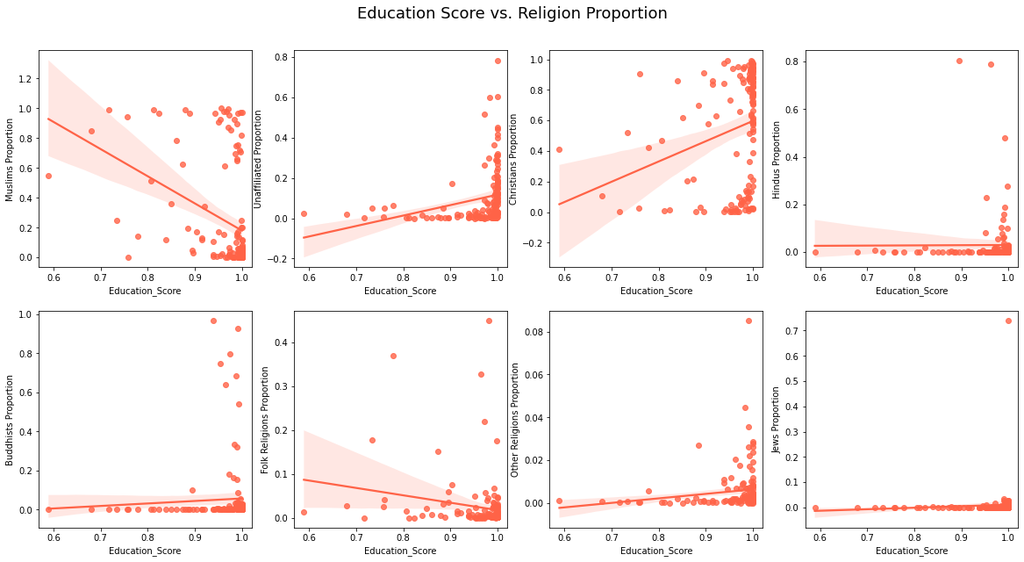

```python
# Create list of dataframe containing education subindex scores and religion proportions
education_list = [df2, df6, df10, df14, df18, df22, df26, df30]

# Create subplots
fig, axes = plt.subplots(2,4,  figsize=(20, 10))
axes = axes.flatten()
fig.suptitle("Education Score vs. Religion Proportion", fontsize=18, y=0.95)

# Loop through list of dataframes and plot scatter points in row of 4 subplots
count=0
for c in prop_religion_list[:4]:
    df = education_list[count]
    ax = sns.regplot(data=df, x='Education_Score', y=c,ax=axes[prop_religion_list.index(c)], color='tomato')
    count+=1

for c in prop_religion_list[4:]:
    df = education_list[count]
    ax = sns.regplot(data=df, x='Education_Score', y=c,ax=axes[prop_religion_list.index(c)], color='tomato')
    count+=1

plt.show()
```

#### Health Score vs. Religion Proportion Visualization

We then plot each country's health score with its proportions for each religion in our dataset. In the plots below, we can see that Christianity has a positive correlation with health score. Islam, Hinduism, and Folk religions have a negative correlation with health score. Unaffiliated religions, Buddhism, Other religions, and Judaism have almost no correlation with health score.

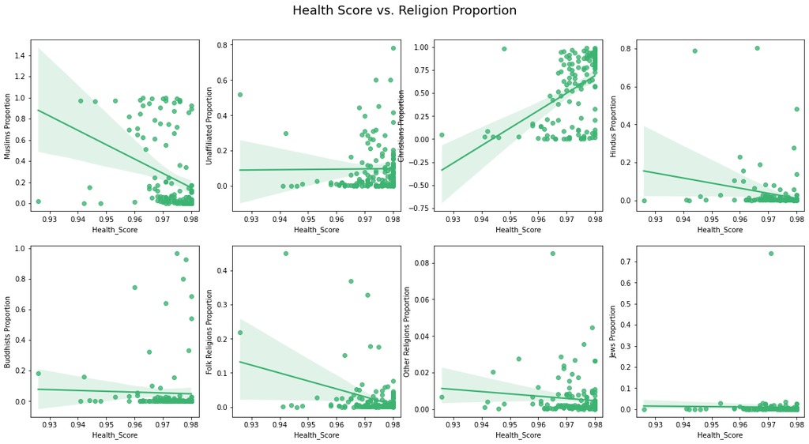

```python
# Create list of dataframe containing health subindex scores and religion proportions
health_list = [df3,df7,df11,df15,df19,df23,df27,df31]

# Create subplots
fig, axes = plt.subplots(2,4,  figsize=(20, 10))
axes = axes.flatten()
fig.suptitle("Health Score vs. Religion Proportion", fontsize=18, y=0.95)

# Loop through list of dataframes and plot scatter points in row of 4 subplots
count=0
for c in prop_religion_list[:4]:
    df = health_list[count]
    ax = sns.regplot(data=df, x='Health_Score', y=c,ax=axes[prop_religion_list.index(c)], color='mediumseagreen')
    count+=1

for c in prop_religion_list[4:]:
    df = health_list[count]
    ax = sns.regplot(data=df, x='Health_Score', y=c,ax=axes[prop_religion_list.index(c)], color='mediumseagreen')
    count+=1

plt.show()
```

#### Political Score vs. Religion Proportion Visualization

Finally, we plot each country's political score with its proportions for each religion in our dataset. In the plots below, we can see that Christianity and Unaffiliated have a positive correlation with political score. Islam and Buddhism have a negative correlation with political score, and Folk religions have a slightly negative correlation with political score. Hinduism, Other, and Judaism have almost no correlation with political score.

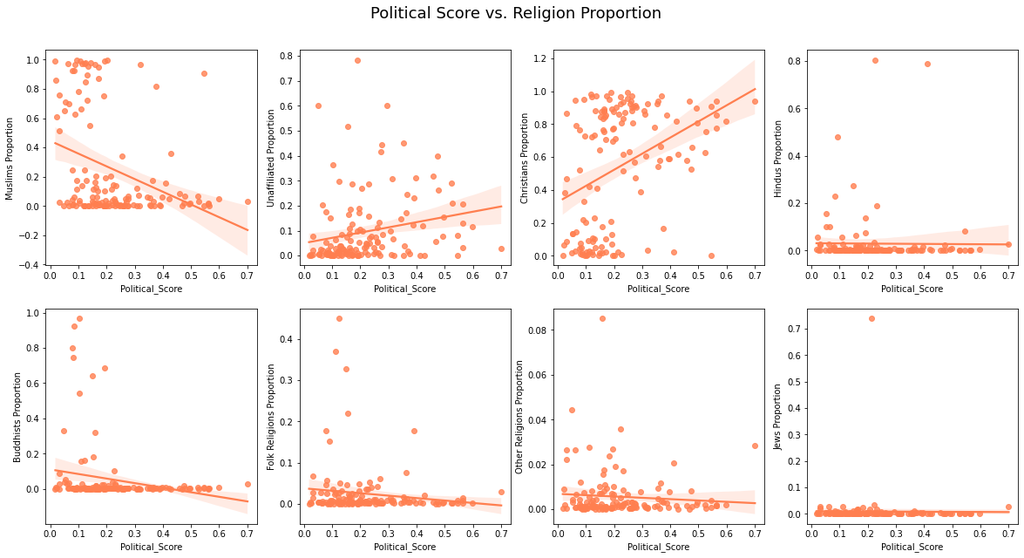

```python
# Create list of dataframe containing health subindex scores and religion proportions
political_list = [df4,df8,df12,df16,df20,df24,df28,df32]

# Create subplots
fig, axes = plt.subplots(2,4,  figsize=(20, 10))
axes = axes.flatten()
fig.suptitle("Political Score vs. Religion Proportion", fontsize=18, y=0.95)

# Loop through list of dataframes and plot scatter points in row of 4 subplots
count=0
for c in prop_religion_list[:4]:
    df = political_list[count]
    ax = sns.regplot(data=df, x='Political_Score', y=c,ax=axes[prop_religion_list.index(c)], color='coral')
    count+=1

for c in prop_religion_list[4:]:
    df = political_list[count]
    ax = sns.regplot(data=df, x='Political_Score', y=c,ax=axes[prop_religion_list.index(c)], color='coral')
    count+=1

plt.show()
```

## **Determining Which Subindex Score is Impacted the Most by Religion**

To determine which subindex score is most impacted by a particular religion(s), we plot a correlation matrix of the Global Gender Gap subindexes and the religion proportions in our dataset.

#### Strongest Positive Correlation Between Religion and Subindex Scores

In the correlation matrix below, we can see that economic, health, and political scores have the highest positive correlation with Christianity with correlation values of 0.5, 0.5, 0.4, respectively. Education score has the highest positive correlation with Unaffiliated and Christianity with both religious groups sharing correlation values of 0.3.

#### Strongest Negative Correlation Between Religion and Subindex Scores

Economic, education, and political scores have the highest negative correlation with Islam with correlation values of -0.6, -0.4, -0.3, respectively. Health score has the strongest negative correlation with Islam and Folk Religions which share a correlation value of -0.3.

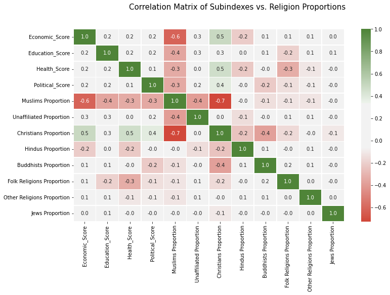

```python
# Draw heatmap with numeric values in each cell
f, ax = plt.subplots(figsize=(12, 7))
f.suptitle('Correlation Matrix of Subindexes vs. Religion Proportions', fontsize=15)
cmap = sns.diverging_palette(15, 120, as_cmap=True, sep=60)
sns.heatmap(subindex_rel_df_2020.corr(), annot=True, fmt=".1f", linewidths=0.5, linecolor='w', ax=ax, cmap=cmap)
plt.show()
```

## **Determining Which Religion Impacts Overall GGGI Score the Most**

To determine which religion impacts overall GGGI score the most, we plot another heatmap of the correlation matrix for overall GGGI score and the religion proportions in our dataset. In the heatmap below, we can see that overall score has the strongest positive correlation with Christianity and the strongest negative correlation with Islam which have correlation values of 0.5 and -0.6, respectively.

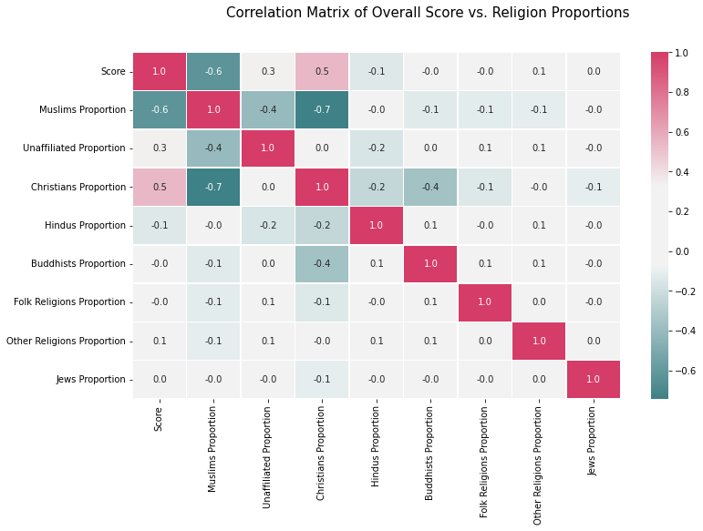

```python
# Create dataframe of overall score and religious proportions
score_rel_df = subindex_rel_df.copy()
score_rel_df = score_rel_df.drop(columns=['All Religions', 'Year', 'level', 'Rank', 'Economic_Rank', 'Education_Rank', 'Health_Rank', 'Political_Rank', 'Nation_fk', \
                                        'Muslims', 'Unaffiliated', 'Christians', 'Hindus', 'Buddhists', 'Folk Religions', 'Other Religions', 'Jews', 'Economic_Score', 'Education_Score', 'Health_Score', 'Political_Score'])

# Draw heatmap with numeric values in each cell
f, ax = plt.subplots(figsize=(12, 7))
f.suptitle('Correlation Matrix of Overall Score vs. Religion Proportions', fontsize=15)
cmap = sns.diverging_palette(200, 1, as_cmap=True, sep=60)
sns.heatmap(score_rel_df.corr(), annot=True, fmt=".1f", linewidths=0.5, linecolor='w', ax=ax, cmap=cmap)
plt.show()
```

# **V. Predicting Gender Gap Index Scores Based on Predicted Religions**

## **Building a Prediction Model Using Religion Proportions**

Using our findings from our first model question, we use the Gender Gap Index Score and Religion proportion variables for each country to predict a country's subindex and/or index scores.

#### Building a Linear Regression Model

First we build and examine a linear regression model on the proportions of each religion to predict the score.

```python
from sklearn.ensemble import RandomForestRegressor
from numpy import mean
from numpy import std
from sklearn.datasets import make_regression
from sklearn.model_selection import cross_val_score
from sklearn.model_selection import RepeatedKFold
from sklearn.ensemble import RandomForestRegressor
from sklearn import datasets, linear_model, metrics
```

```python
#Build and train model based on religious features
X = world_score[["Christians_porp",	"Muslims_porp",	"Unaffiliated_porp",	"Hindus_porp",	"Buddhists_porp",	"Folk Religions porp",	"Other_porp", "Jews_porp"]]
y = world_score.Score
from sklearn.model_selection import train_test_split
X_train, X_test, y_train, y_test = train_test_split(X, y, test_size=0.2, random_state=1)
reg = linear_model.LinearRegression()
reg.fit(X_train.values, y_train.values)
print('Coefficients: ', reg.coef_)
print('Variance score: {}'.format(reg.score(X_test.values, y_test.values)))#as you can see our score is very low
print('Intercept:', reg.intercept_)
```

```
Coefficients:  [ 0.52719229  0.43099553  0.60547662  0.46863548  0.49597554  0.40167294
 -0.74000635  0.55008101]
Variance score: 0.436354188479781
Intercept: 0.1837439499190786
```

Based on the model above we can get the equation:

$y = x_{1}0.52719229 + x_{2}0.43099553 + x_{3}0.60547662 + x_{4}0.46863548 + x_{5}0.49597554 + x_{6}0.40167294 + x_{7}-0.74000635 + x_{8}0.55008101 + 0.1837439499190786$

We also see that the variance score is not good at 0.436, ideally we would want a score closer to 1.0.

#### Building a Random Forest Regression Model

To improve the variance score, we can use a random forest regressor since there are no signs of linearity. Overall, this method of regression yields a much better result with a variance score of 0.88 and a very good MAE value of -0.016.

```python
reg = RandomForestRegressor(n_estimators=10, max_features=8)
reg.fit(X_train.values, y_train.values)
print('Variance score: {}'.format(reg.score(X_test.values, y_test.values)))
```

```
Variance score: 0.8814052005914517
```

```python
cv = RepeatedKFold(n_splits=10, n_repeats=3, random_state=1)
n_scores = cross_val_score(reg, X, y, scoring='neg_mean_absolute_error', cv=cv, n_jobs=-1, error_score='raise')
# report performance
print('MAE: %.3f (%.3f)' % (mean(n_scores), std(n_scores)))
```

```
MAE: -0.016 (0.000)
```

```python
#predicting off of the data from Fiji and it should return about 0.626 as the score
predicted = reg.predict([[0.639535,	0.05814,	0.011628,	0.27907,	0.011628,	0.011628,	0.011628,	0.011628]])
print(predicted)
```

```
[0.64258217]
```

This model is based off of the features of proportions. Using a Random Forest Regression, we find that you can use religion to predict the scores. The results are all pretty close to the actual scores.

#### Understanding Our Random Forest Regression Model

We then compare the data from the actual score and the predicted score to compare the linearity assumption. In the graph below, we can see that the relationship between actual and predicted score is linear and that there is a relatively strong correlation between the actual and predicted score.

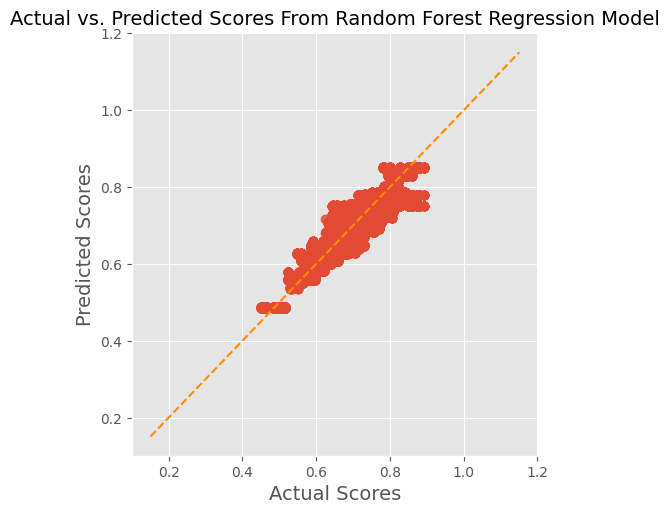

```python
world_score['score_pred'] = reg.predict(X)
world_score['residual'] = world_score["Score"]-world_score["score_pred"]

plt.figure(figsize=(10,5))
sns.lmplot(x='Score', y='score_pred', data=world_score, fit_reg=False, height=5)

# Plotting the diagonal line
line_coords = np.arange(world_score[['Score', 'score_pred']].min().min()- 0.3,
                        world_score[['Score', 'score_pred']].max().max()+0.3)
plt.plot(line_coords, line_coords,  # X and y points
         color='darkorange', linestyle='--')

plt.ylabel('Predicted Scores', fontsize=14)
plt.xlabel('Actual Scores', fontsize=14)
plt.title('Actual vs. Predicted Scores From Random Forest Regression Model', fontsize=14)
plt.show()
```

Next, we graph the predicted scores and the residuals to analyze how accurate our predicted scores are. We can see that the graph below is a good residual plot because it has a high density of points close to the origin and is symmetric about the origin. Thus, our random forest regression model does a good job at predicting scores.

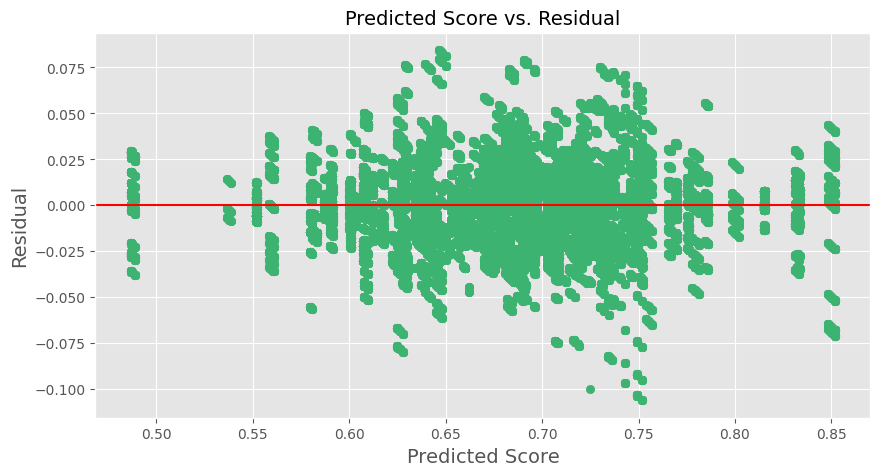

```python
plt.figure(figsize=(10,5))
plt.scatter(world_score["score_pred"], world_score["residual"], color = 'mediumseagreen')
plt.axhline(y=0.0, color='r', linestyle='-')
plt.title('Predicted Score vs. Residual', fontsize=14)
plt.xlabel('Predicted Score', fontsize=14)
plt.ylabel('Residual', fontsize=14)
plt.show()
```

## **Building a Prediction Model Based Off of Major Religion**

Next we examined a model using countrys' predicted dominant religion, instead of proportions of all religions in each country. This model however, is not very useful and yields a variance of 0.377.

```python
world_score['Max'] = world_score[["Christians_porp",	"Muslims_porp",	"Unaffiliated_porp",	"Hindus_porp",	"Buddhists_porp",	"Folk Religions porp",	"Other_porp",	"Jews_porp"]].idxmax(axis=1)
```

```python
#Build and train model based on religious features
X = world_score[["Max"]]
X=pd.get_dummies(X)
y = world_score.Score
from sklearn.model_selection import train_test_split
X_train, X_test, y_train, y_test = train_test_split(X, y, test_size=0.2, random_state=1)
reg = RandomForestRegressor(n_estimators=10, max_features=1)
reg.fit(X_train.values, y_train.values)
print('Variance score: {}'.format(reg.score(X_test.values, y_test.values)))
```

```
Variance score: 0.3775745311959273
```

## **Building a Prediction Model with Muslim Proportions**

Below we build the same random forest regression model but only having the Muslim proportions as features. We decided to try this model with this feature since looking at the correlation matrix, Muslim proportions had a higher correlation value with the score. As we can see below, the variance score is still pretty high at 0.86. The $R^{2}$ value is also very high which is a positive sign.

```python
#Build and train model based on religious features
X = world_score[["Muslims_porp"]]
y = world_score.Score
from sklearn.model_selection import train_test_split
X_train, X_test, y_train, y_test = train_test_split(X, y, test_size=0.2, random_state=1)
#reg = linear_model.LinearRegression()
#reg.fit(X_train.values, y_train.values)
reg = RandomForestRegressor(n_estimators=10, max_features=1)
reg.fit(X_train.values, y_train.values)
print('Variance score: {}'.format(reg.score(X_test.values, y_test.values)))
```

```
Variance score: 0.8641835721718514
```

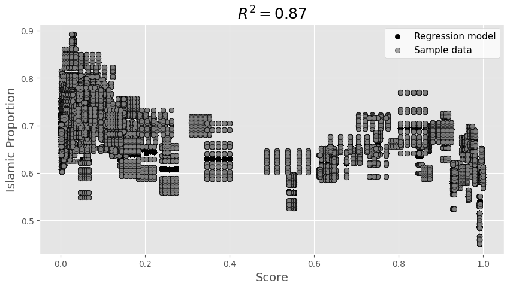

```python
#Looking how than Islamic proportions effects overall score
response = reg.predict(X)
r2 = reg.score(X, y)

plt.style.use('default')
plt.style.use('ggplot')
fig, ax = plt.subplots(figsize=(10, 5))
ax.scatter(X, response, color='k', label='Regression model')
ax.scatter(X, y, edgecolor='k', facecolor='grey', alpha=0.7, label='Sample data')

ax.set_ylabel('Islamic Proportion', fontsize=14)
ax.set_xlabel('Score', fontsize=14)
ax.legend(facecolor='white', fontsize=11)
ax.set_title('$R^2= %.2f$' % r2, fontsize=18)
plt.show()
```

## **Building a Prediction Model with Christianity Proportions**

```python
#Build and train model based on religious features
X = world_score[["Christians_porp"]]
y = world_score.Score
from sklearn.model_selection import train_test_split
X_train, X_test, y_train, y_test = train_test_split(X, y, test_size=0.2, random_state=1)
#reg = linear_model.LinearRegression()
#reg.fit(X_train.values, y_train.values)
reg = RandomForestRegressor(n_estimators=10, max_features=1)
reg.fit(X_train.values, y_train.values)
print('Variance score: {}'.format(reg.score(X_test.values, y_test.values)))
```

```
Variance score: 0.8797764959833853
```

[figure not shown]

```python
#Looking how the Christianity proportions effects overall score
response = reg.predict(X)
r2 = reg.score(X, y)

plt.style.use('default')
plt.style.use('ggplot')
fig, ax = plt.subplots(figsize=(10, 5))
ax.scatter(X, response, color='k', label='Regression model')
ax.scatter(X, y, edgecolor='k', facecolor='grey', alpha=0.7, label='Sample data')

ax.set_ylabel('Christian Proportion', fontsize=14)
ax.set_xlabel('Score', fontsize=14)
ax.legend(facecolor='white', fontsize=11)
ax.set_title('$R^2= %.2f$' % r2, fontsize=18)
```

# **VI. Conclusion**

## **Answering Our Initial Questions**

Through the completion of this final tutorial, we have gained several insights relating to our initial questions:

**1. How does religion impact a country's gender gap subindex scores in terms of health, education, economics, and politics?**  
Our analysis shows that countries with a higher number of members of Christianity tend to have a higher economic, education, health, and political score. Moreover, countries with a higher number of members of Islam tend to have a lower economic, education, health, and political score. Other religious groups that we evaluated including Unaffiliated, Hinduism, Buddhism, Folk religions, Judaism, and other religions, do not appear to have a strong impact on a country's subindex scores. While our analysis resulted in the above conclusions about countries with a more concentrated number of Christianity and Islam, the positive correlation values did not exceed 0.5 and negative correlation values did not exceed -0.6. Thus, there is not a perfect positive or negative correlation between these religions and the GGGI subindexes. We can conclude that there are most likely additional country characteristics having a greater impact on subindex scores than religion. More research should be done to evaluate these additional country characteristics that may impact its subindex scores.

**2. Are particular major religions related to a lower overall gender gap index score?**  
Similar to our findings in the question above, our analysis shows that the number of members of Christianity and Islam impact the overall GGGI score of a country. Countries with a higher number of members of Christianity tend to have a higher overall score, and countries with a higher number of members of Islam tend to have a lower overall score. Other religious groups that we evaluated including Unaffiliated, Hinduism, Buddhism, Folk religions, Judaism, and other religions, do not appear to have a strong impact on a country's overall score. Again, more research should be done to account for the additional factors that could also impact a country's overall score.

**3. Can we predict how a country's gender gap index score will change over time based on the prediction of its future major religion?**

## **More Resources on the Gender Gap**

Thank you for taking the time to learn more about our Exploratory Analysis on the Global Gender Gap Index and Religion! We hope that you found it interesting and gained some knowledge about the global gender gap. In case you're interested in learning more about the gender gap, we've listed a few readings to further your learning:

[TIME: The Global Gender Gap Will Take an Extra 36 Years to Close After the COVID-19 Pandemic, Report Finds](https://time.com/5951101/global-gender-gap-135-years/)

[United Nations: Women and Girls – Closing the Gender Gap](https://www.un.org/en/un75/women_girls_closing_gender_gap)

[U.S. News: Around the World, the Greatest Gender Disparities Are in Politics](https://www.usnews.com/news/best-countries/articles/2021-04-13/the-greatest-gender-inequality-in-the-world-is-in-politics)

*Dear Ijeawele, or A Feminist Manifesto in Fifteen Suggestions* by Chimamanda Ngozi Adichie